# EDA_Assignment-Diamonds-Dataset-III

Sbanerjee

October 31, 2015

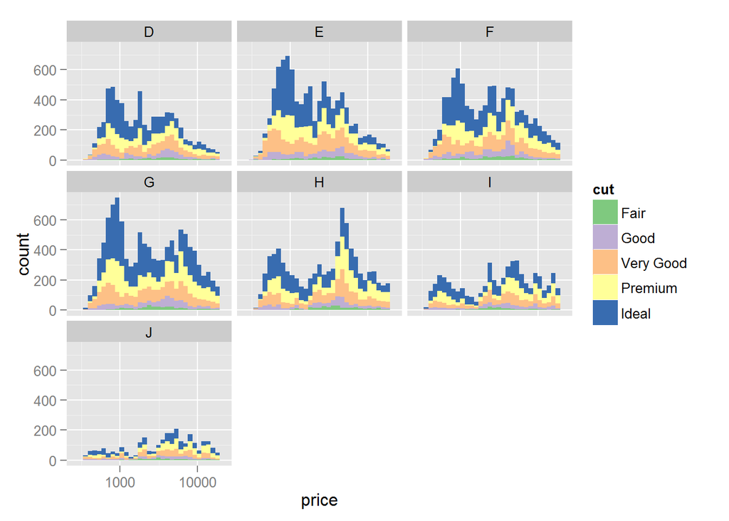

```r
library("ggplot2")
library("RColorBrewer")
data("diamonds")


#Histogram of Price, using Cut as Color faceted by Color

graph <- ggplot(data = diamonds, aes(x = price, fill = cut))+
  geom_histogram()+
  scale_fill_brewer(type = 'qual')+
  scale_y_continuous(breaks = seq(0,800,200))+
  scale_x_log10()+
  facet_wrap(~ color)

suppressMessages(print(graph))
```

ScatterPlot of price vs table and color the points by the cut of the diamond.

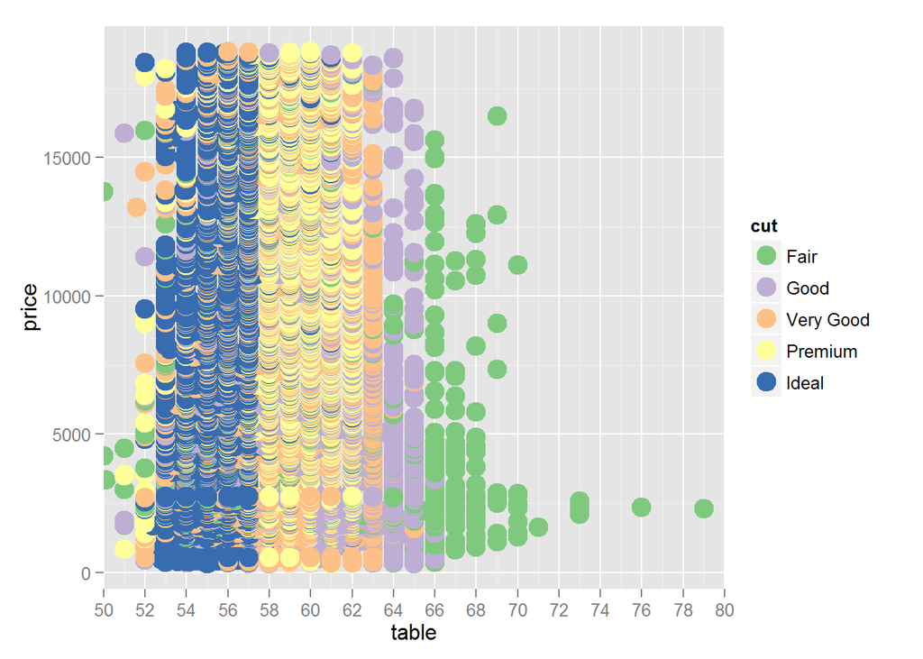

```r
scplot <-
  ggplot(data = diamonds, aes(x = table, y = price  , color = cut))+
  geom_point(size = 5, shape = 19)+
  scale_x_continuous(breaks = seq(0,100,2))+
  coord_cartesian(xlim =  c(50,80))+
  scale_color_brewer(type = 'qual')

suppressMessages(print(scplot))
```

Create a scatterplot of diamond price vs.volume (x * y * z) and color the points by the clarity of diamonds. Use scale on the y-axis to take the log10 of price. You should also omit the top 1% of diamond volumes from the plot.

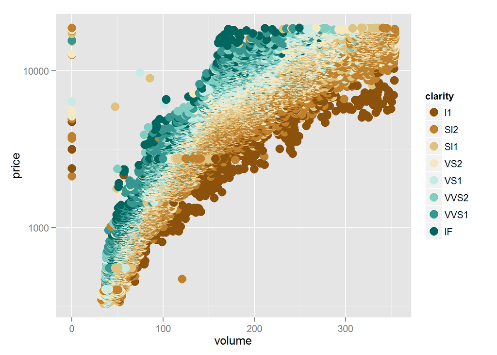

```r
diamonds$volume = with(diamonds, x * y * z)

scplot2 <-
  ggplot(data = subset(diamonds, diamonds$volume < quantile(diamonds$volume,0.99)), aes(y = price, x = volume  , color = clarity))+
  geom_point(size = 4)+
  scale_y_log10()+
  scale_color_brewer(type = 'div')

suppressMessages(print(scplot2))
```

Many interesting variables are derived from two or more others.For example, we might wonder how much of a person’s network on a service like Facebook the user actively initiated. Two users with the same degree (or number of friends) might be very different if one initiated most of those connections on the service, while the other initiated very few. So it could be useful to consider this proportion of existing friendships that the user initiated. This might be a good predictor of how active a user is compared with their peers, or other traits, such as personality (i.e., is this person an extrovert?).

```r
setwd('C:/Users/Subhankar/Desktop/R Programs/EDA_Course_Materials/lesson5')
pf <- read.csv("pseudo_facebook.tsv", sep = "\t")


pf$prop_initiated <- pf$friendships_initiated/pf$friend_count

pf$year_joined = floor(2014 - pf$tenure/365)
pf$year_joined.bucket <- cut(pf$year_joined,c(2004, 2009, 2011, 2012, 2014))

summary(pf$prop_initiated)
```

```
##    Min. 1st Qu.  Median    Mean 3rd Qu.    Max.    NA's
##  0.0000  0.4524  0.6250  0.6078  0.7838  1.0000    1962
```

```
## geom_smooth: method="auto" and size of largest group is >=1000, so using gam with formula: y ~ s(x, bs = "cs"). Use 'method = x' to change the smoothing method.
```

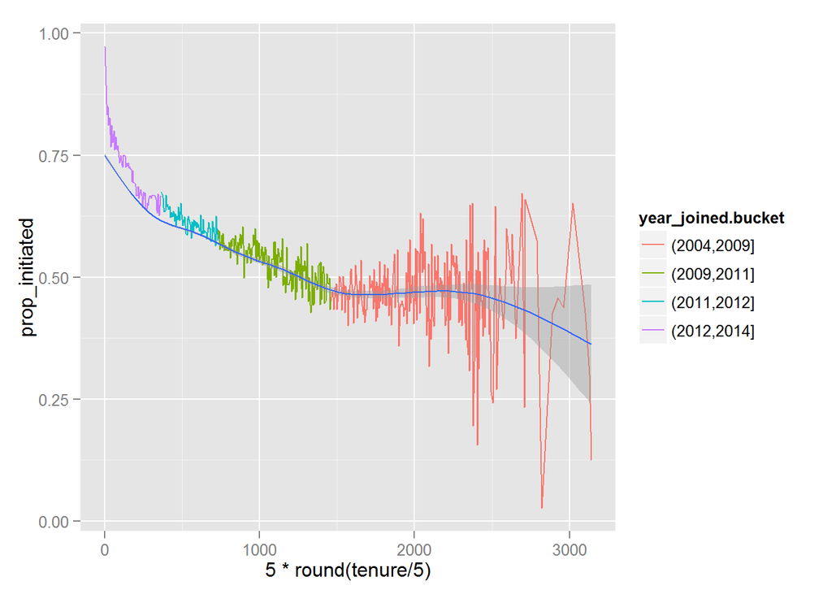

```r
scplot3 <-

  ggplot(data = subset(pf, friend_count > 0), aes(y = prop_initiated, x = 5 * round(tenure / 5)))+
  scale_x_continuous(breaks = seq(0,3000,1000) )+
  geom_line(aes(color = year_joined.bucket), stat = "summary", fun.y = "median")

scplot3+ geom_smooth()
```

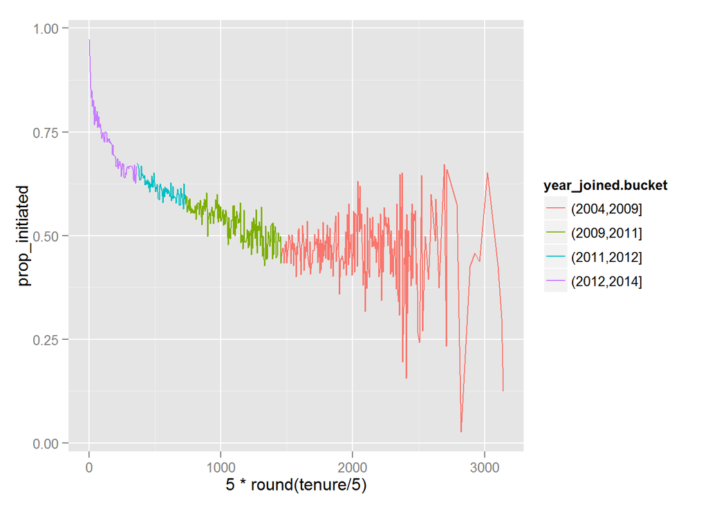

```r
suppressMessages(print(scplot3))
```